# Analyzing Individual BGG Users

Phil Henrickson

2022-01-02

# **Flops3’s** BoardGameGeek Collection

This notebook contains a set of analyses for the selected user’s boardgamegeek collection. The bulk of the analysis is focused on building a user-specific predictive model to predict the games that Flops3 is likely to own. This enables to ask questions like, based on the games the user currently owns, what games are a good fit for their collection? What upcoming games are they likely to purchase?

This analysis is based on data from BoardGameGeek that was last updated on **2021-12-20.**

# 1 Collection Overview

We can look at a basic description of the number of games that the user owns, has rated, has previously owned, etc.

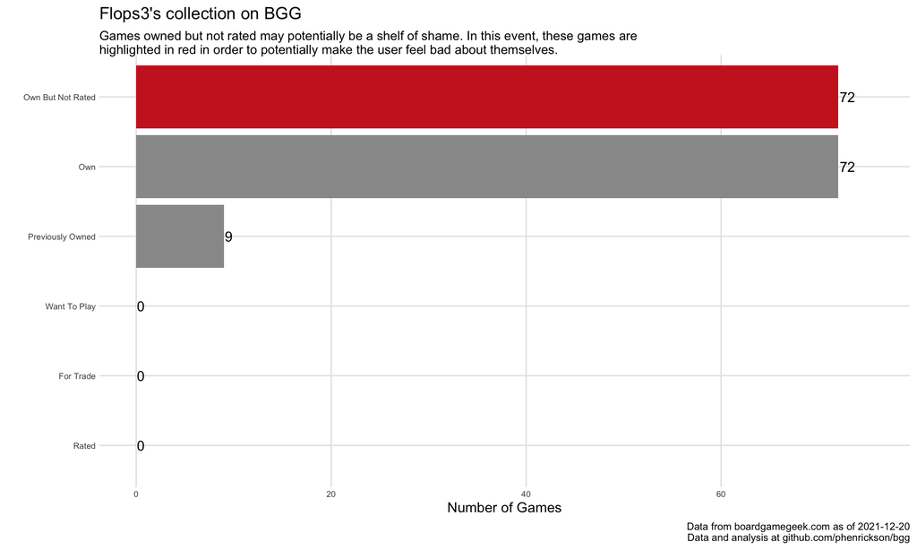

What years has the user owned/rated games from? While we can’t see when a user added or removed a game from their collection, we can look at their collection by the years in which their games were published.

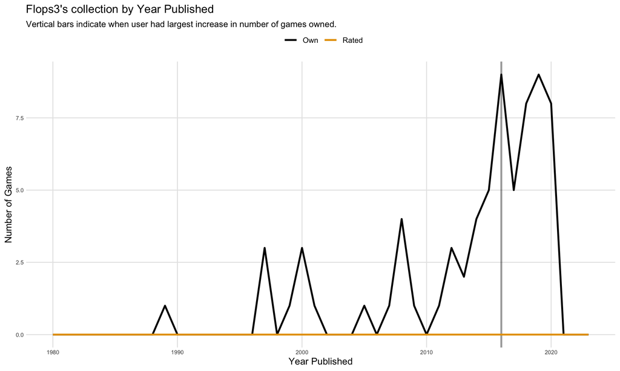

## 1.1 What types of games does Flops3 own?

We can look at the most frequent types of categories, mechanics, designers, and artists that appear in a user’s collection.

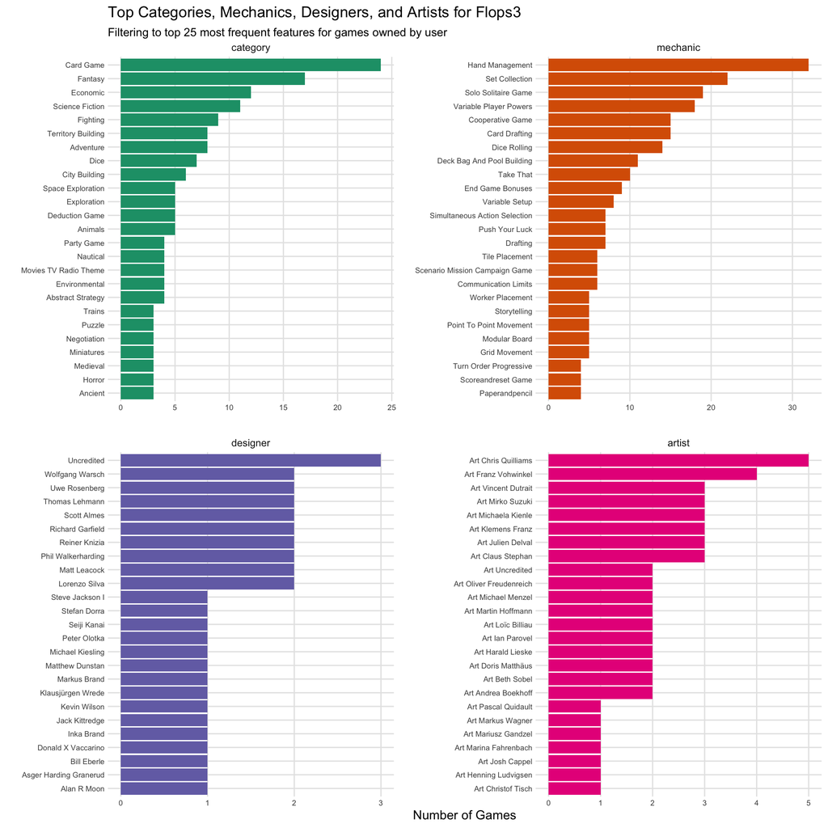

# 2 Modeling **Flops3’s** Collection

| username | dataset | period | games_owned | games_rated | games_played |
| --- | --- | --- | --- | --- | --- |
| Flops3 | training | published before 2020 | 62 | 0 | 71 |
| Flops3 | test | published 2020 or later | 8 | 0 | 8 |

There are two main (binary) outcomes we will be modeling for the user.

The first, **own** refers to whether the user currently lists a game as owned in their collection. The second, **played** refers to whether the user currently owns, has rated, or previously owned a game. This means the latter will generally have a larger list of games, but may still be a useful category to examine for people who play lots of games without necessarily owning them.

We will train predictive models to learn the probability that the user will own or play individual games based on their features.

## 2.1 Coefficients for Flops3

We can examine coefficients from the trained modes, which are penalized logistic regressions fit to our two main outcomes. Positive values indicate that a feature increases a user’s probabilility of owning/rating a game, while negative values indicate a feature decreases the probability.

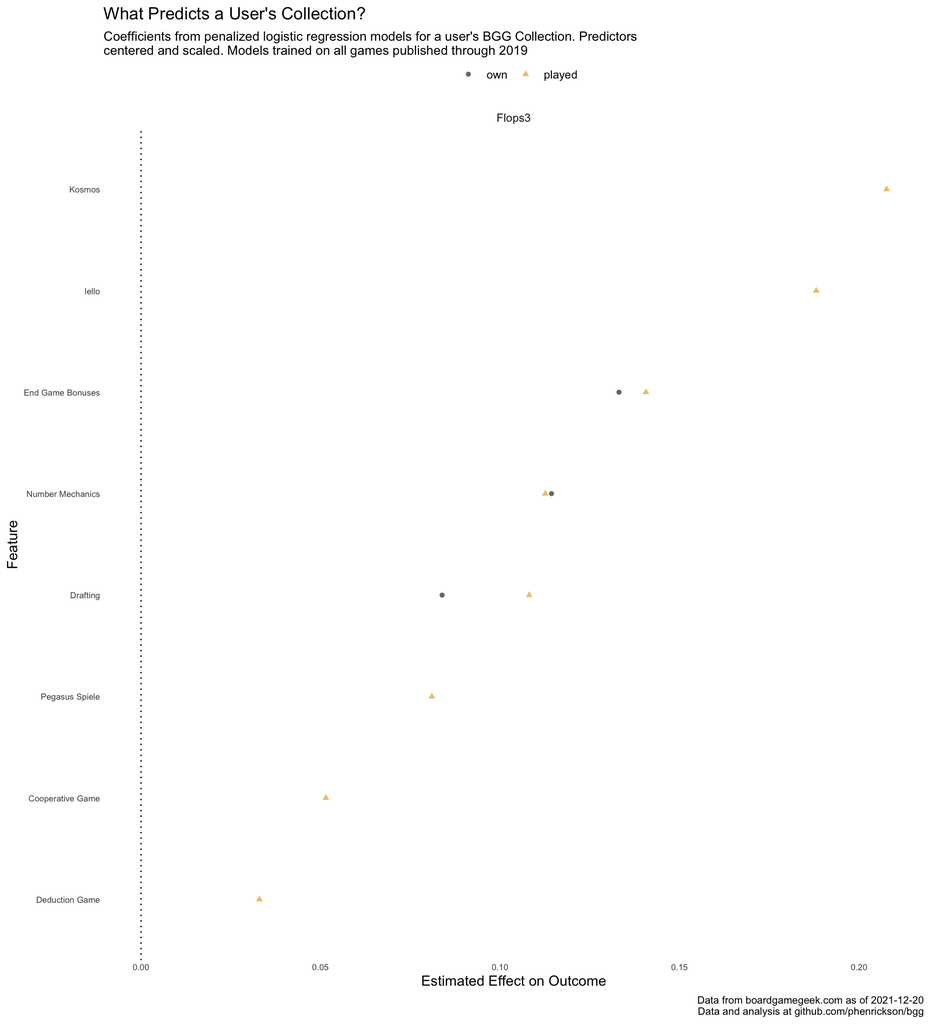

## 2.2 Visualizing Predictors for Flops3’s Collection

Why did the model identify these features? We can make density plots of the important features for predicting whether the user owned a game. Blue indicates the density for games owned by the user, while grey indicates the density for games not owned by the user.

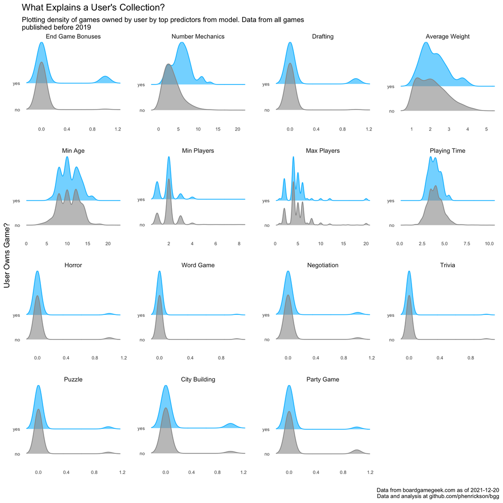

Binary predictors can be difficult to see with this visualization, so we can also directly examine the percentage of games in a user’s collection with a predictor vs the percentage of all games with that predictor.

| username | Feature | % of Games with Feature In_Collection | % of Games with Feature All_Games | Ratio |
| --- | --- | --- | --- | --- |
| Flops3 | End Game Bonuses | 14.5% | 1.2% | 12.2 |
| Flops3 | Drafting | 11.3% | 1.0% | 11.6 |
| Flops3 | City Building | 9.7% | 4.2% | 2.3 |
| Flops3 | Trains | 4.8% | 2.2% | 2.2 |
| Flops3 | Puzzle | 4.8% | 3.4% | 1.4 |
| Flops3 | Fighting | 12.9% | 9.1% | 1.4 |
| Flops3 | Negotiation | 4.8% | 3.6% | 1.3 |
| Flops3 | Deduction Game | 8.1% | 6.4% | 1.3 |
| Flops3 | Racing | 3.2% | 2.8% | 1.2 |
| Flops3 | Ancient | 4.8% | 4.5% | 1.1 |
| Flops3 | Word Game | 1.6% | 1.8% | 0.9 |
| Flops3 | Trivia | 1.6% | 1.8% | 0.9 |
| Flops3 | Murdermystery | 1.6% | 1.8% | 0.9 |
| Flops3 | Horror | 3.2% | 4.0% | 0.8 |
| Flops3 | Medieval | 4.8% | 6.3% | 0.8 |
| Flops3 | Sports | 1.6% | 2.0% | 0.8 |
| Flops3 | Party Game | 4.8% | 8.5% | 0.6 |
| Flops3 | Miniatures | 3.2% | 5.4% | 0.6 |
| Flops3 | Realtime | 1.6% | 4.2% | 0.4 |
| Flops3 | Action Dexterity | 1.6% | 4.8% | 0.3 |
| Flops3 | Mafia | 0.0% | 0.7% | 0.0 |
| Flops3 | Prehistoric | 0.0% | 1.0% | 0.0 |
| Flops3 | Childrens Game | 0.0% | 5.7% | 0.0 |
| Flops3 | Memory Game | 0.0% | 1.7% | 0.0 |
| Flops3 | World War II | 0.0% | 4.0% | 0.0 |

# 3 Assess Model’s Performance on Training Set

Before predicting games in upcoming years, we can examine how well the model did and what games it liked in the training set. In this case, we used resampling techniques (cross validation) to ensure that the model had not seen a game before making its predictions.

## 3.1 Separation Plot

An easy way to examine the performance of classification model is to view a separation plot. We plot the predicted probabilities from the model for every game (from resampling) from lowest to highest. We then overlay a blue line for any game that the user does own. A good classifier is one that is able to *separate* the blue (games owned by the user) from the white (games not owned by the user), with most of the blue occurring at the highest probabilities (right side of the chart).

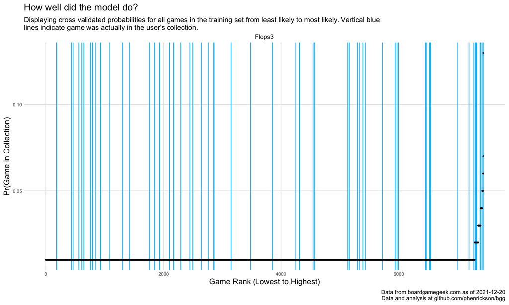

## 3.2 Top Games for **Flops3** from Training Set

We can display this information in table form, displaying the 100 games with the highest probability of ownership, adding a blue line when the user does own the game.

| username | yearpublished | game_id | name | pred_played | pred_own | actual_played | actual_own |
| --- | --- | --- | --- | --- | --- | --- | --- |
| Flops3 | 2019 | 283863 | The Magnificent | 0.21 | 0.13 | 0 | 0 |
| Flops3 | 2018 | 205896 | Rising Sun | 0.17 | 0.07 | 0 | 0 |
| Flops3 | 2018 | 244711 | Newton | 0.14 | 0.06 | 0 | 0 |
| Flops3 | 2019 | 271324 | It's a Wonderful World | 0.09 | 0.06 | 0 | 0 |
| Flops3 | 2016 | 167791 | Terraforming Mars | 0.10 | 0.06 | 1 | 1 |
| Flops3 | 2016 | 177590 | 13 Days: The Cuban Missile Crisis | 0.03 | 0.05 | 0 | 0 |
| Flops3 | 2010 | 73439 | Troyes | 0.04 | 0.05 | 0 | 0 |
| Flops3 | 2015 | 181687 | The Pursuit of Happiness | 0.08 | 0.05 | 0 | 0 |
| Flops3 | 2017 | 184921 | Bunny Kingdom | 0.20 | 0.05 | 0 | 0 |
| Flops3 | 2019 | 261342 | Old West Empresario | 0.06 | 0.05 | 0 | 0 |
| Flops3 | 2019 | 269603 | Minecraft: Builders & Biomes | 0.04 | 0.05 | 0 | 0 |
| Flops3 | 2017 | 220308 | Gaia Project | 0.08 | 0.05 | 0 | 0 |
| Flops3 | 2016 | 185589 | Islebound | 0.09 | 0.05 | 0 | 0 |
| Flops3 | 2019 | 276025 | Maracaibo | 0.09 | 0.05 | 0 | 0 |
| Flops3 | 2019 | 260710 | Amul | 0.09 | 0.05 | 0 | 0 |
| Flops3 | 2016 | 192291 | Sushi Go Party! | 0.07 | 0.05 | 0 | 0 |
| Flops3 | 2016 | 72321 | The Networks | 0.04 | 0.05 | 1 | 1 |
| Flops3 | 2019 | 266192 | Wingspan | 0.09 | 0.05 | 1 | 1 |
| Flops3 | 2017 | 217861 | Paper Tales | 0.15 | 0.05 | 0 | 0 |
| Flops3 | 2013 | 133473 | Sushi Go! | 0.06 | 0.05 | 0 | 0 |
| Flops3 | 2012 | 118048 | Targi | 0.29 | 0.04 | 0 | 0 |
| Flops3 | 2016 | 196340 | Yokohama | 0.03 | 0.04 | 0 | 0 |
| Flops3 | 2019 | 240567 | Chocolate Factory | 0.04 | 0.04 | 0 | 0 |
| Flops3 | 2018 | 245638 | Coimbra | 0.04 | 0.04 | 0 | 0 |
| Flops3 | 2013 | 52461 | Legacy: The Testament of Duke de Crecy | 0.21 | 0.04 | 0 | 0 |
| Flops3 | 2016 | 176083 | Hit Z Road | 0.05 | 0.04 | 0 | 0 |
| Flops3 | 2017 | 218603 | Photosynthesis | 0.04 | 0.04 | 0 | 0 |
| Flops3 | 2019 | 257066 | Sierra West | 0.07 | 0.04 | 0 | 0 |
| Flops3 | 2019 | 270971 | Era: Medieval Age | 0.06 | 0.04 | 0 | 0 |
| Flops3 | 2018 | 247763 | Underwater Cities | 0.04 | 0.04 | 0 | 0 |

[output cut: 70 more lines]

We can also more formally assess how well the model did in resampling by looking at the area under the receiver operating characteristic. A perfect model would receive a score of 1, while a model that cannot predict the outcome will default to a score of 0.5. The extent to which something is a *good* score depends on the setting, but generally anything in the .8 to .9 range is very good while the .7 to .8 range is perfectly acceptable.

| username | outcome_type | .metric | .estimator | .estimate |
| --- | --- | --- | --- | --- |
| Flops3 | own | roc_auc | binary | 0.725 |
| Flops3 | played | roc_auc | binary | 0.770 |

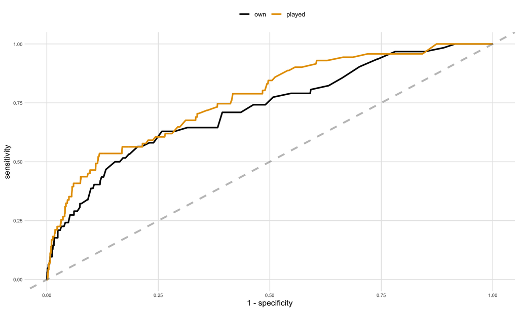

Another way to think about the model performance is to view its lift, or its ability to detect the positive outcomes over that of a null model. High lift indicates the model can much more quickly find all of the positive outcomes (in this case, games owned or played by the user), while a model with no lift is no better than random guessing.

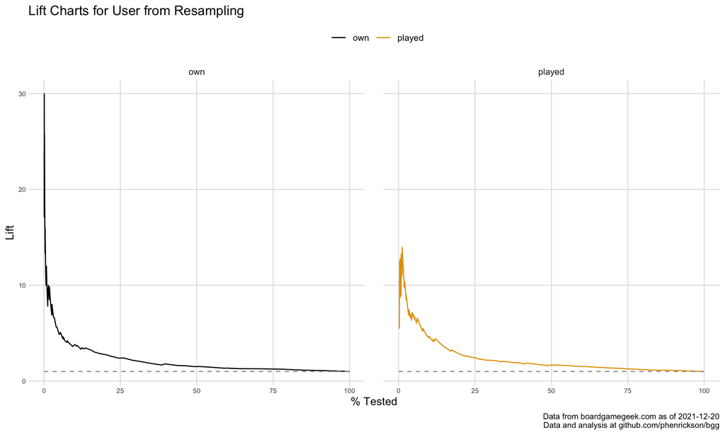

## 3.3 Most and Least Likely Games

What games does the model think Flops3 is **most likely to own** that are **not** in their collection?

| username | yearpublished | game_id | name | pred_own | actual_own |
| --- | --- | --- | --- | --- | --- |
| Flops3 | 2019 | 283863 | The Magnificent | 0.13 | 0 |
| Flops3 | 2018 | 205896 | Rising Sun | 0.07 | 0 |
| Flops3 | 2018 | 244711 | Newton | 0.06 | 0 |
| Flops3 | 2019 | 271324 | It's a Wonderful World | 0.06 | 0 |
| Flops3 | 2016 | 177590 | 13 Days: The Cuban Missile Crisis | 0.05 | 0 |

What games does the model think Flops3 is **least likely to own** that **are** in their collection?

| username | yearpublished | game_id | name | pred_own | actual_own |
| --- | --- | --- | --- | --- | --- |
| Flops3 | 1997 | 132 | Caesar & Cleopatra | 0.01 | 1 |
| Flops3 | 1900 | 171 | Chess | 0.01 | 1 |
| Flops3 | 2019 | 285775 | KeyForge: Worlds Collide | 0.01 | 1 |
| Flops3 | 1999 | 50 | Lost Cities | 0.01 | 1 |
| Flops3 | 2009 | 54043 | Jaipur | 0.01 | 1 |

## 3.4 Top Games by Year

Top 25 games most likely to be owned by the user in each year, highlighting in blue the games that the user has owned/played.

| rank | 2011 | 2012 | 2013 | 2014 | 2015 | 2016 | 2017 | 2018 | 2019 |
| --- | --- | --- | --- | --- | --- | --- | --- | --- | --- |
| 1 | Takenoko | Targi | Sushi Go! | Spurs: A Tale in the Old West | The Pursuit of Happiness | Terraforming Mars | Bunny Kingdom | Rising Sun | The Magnificent |
| 2 | Band of Brothers: Screaming Eagles | Kairo | Legacy: The Testament of Duke de Crecy | Castles of Mad King Ludwig | Far Space Foundry | 13 Days: The Cuban Missile Crisis | Gaia Project | Newton | It's a Wonderful World |
| 3 | A Few Acres of Snow | Keyflower | Russian Railroads | Five Tribes | The Bloody Inn | Islebound | Paper Tales | Coimbra | Old West Empresario |
| 4 | Sekigahara: The Unification of Japan | Terra Mystica | Brew Crafters | La Granja | Grand Austria Hotel | Sushi Go Party! | Photosynthesis | Underwater Cities | Minecraft: Builders & Biomes |
| 5 | Fighting Formations: Grossdeutschland Motorized Infantry Division | Il Vecchio | Circus Train (Second Edition) | Praetor | Best Treehouse Ever | The Networks | Sagrada | Blue Lagoon | Maracaibo |
| 6 | No Retreat! The Russian Front | Santa Cruz | Dungeon Command: Blood of Gruumsh | Patchwork | Between Two Cities | Yokohama | Calimala | Western Legends | Amul |
| 7 | Nightfighter | The Manhattan Project | Band of Brothers: Ghost Panzer | Imperial Settlers | Tiny Epic Galaxies | Hit Z Road | Pulsar 2849 | Kero | Wingspan |
| 8 | Space Infantry | Suburbia | BattleLore: Second Edition | Sheep & Thief | FUSE | Avenue | Azul | Dice Hospital | Chocolate Factory |
| 9 | No Peace Without Spain!: The War of the Spanish Succession 1702-1713 | Tzolk'in: The Mayan Calendar | No Retreat!: The North African Front | Alchemists | Haspelknecht | Thief's Market | Harvest Dice | Everdell | Sierra West |
| 10 | FAB: Sicily | Among the Stars | Crusade and Revolution: The Spanish Civil War, 1936-1939 | Camel Up | Blood Rage | Scythe | Twilight Imperium: Fourth Edition | Forum Trajanum | Era: Medieval Age |
| 11 | Revolver | Tokaido | Sedition Wars: Battle for Alabaster | Fallen | 504 | Inis | Journal 29: Interactive Book Game | Pax Emancipation | Pipeline |
| 12 | 1955: The War of Espionage | Kings of War | Dungeon Twister: The Card Game | Holdfast: Russia 1941-42 | New Salem | Roll Player | Techno Bowl: Arcade Football Unplugged | Planet | Clank!: Legacy – Acquisitions Incorporated |
| 13 | Test of Fire: Bull Run 1861 | Mage Wars Arena | Invaders | Heroes of Normandie | Nevermore | Clank!: A Deck-Building Adventure | Commands & Colors Tricorne: The American Revolution | Azul: Stained Glass of Sintra | Tiny Towns |
| 14 | Steam Torpedo: First Contact | Dungeon Command: Sting of Lolth | Risk: Plants vs. Zombies | Strife: Legacy of the Eternals | RYŪ | La Granja: No Siesta | Runewars Miniatures Game | That's Pretty Clever! | Ragusa |
| 15 | Yomi | Dungeon Command: Heart of Cormyr | Metallum | Star Wars: Empire vs. Rebellion | Stronghold: 2nd edition | Imhotep | Aristeia! | Gingerbread House | De Vulgari Eloquentia: Deluxe Edition |
| 16 | Laser Chess | Dungeon Command: Curse of Undeath | France '40 | Fleet Commander: 1 – Ignition | Wing Leader: Victories 1940-1942 | Agricola (Revised Edition) | Fields of Despair: France 1914-1918 | The Little Flower Shop | Paris: La Cité de la Lumière |
| 17 | Omen: A Reign of War | DreadBall: The Futuristic Sports Game | Castellan | Jäger und Späher | Warhammer Age of Sigmar | Junk Art | Enemy Coast Ahead: The Doolittle Raid | Key Flow | The Isle of Cats |
| 18 | Ascension: Return of the Fallen | Kingdom of Heaven: The Crusader States 1097-1291 | Island Siege | Space Hulk (Fourth Edition) | The U.S. Civil War | Dynasties: Heirate & Herrsche | 13 Minutes: The Cuban Missile Crisis, 1962 | Architects of the West Kingdom | Aquatica |
| 19 | Drako: Dragon & Dwarves | Celles: The Ardennes, December 23-27, 1944 | Smash Up: Awesome Level 9000 | Wir sind das Volk! | Guild Ball | The Manhattan Project: Energy Empire | Tak | Kodama Duo | Azul: Summer Pavilion |
| 20 | Kulami | Antike Duellum | Pixel Tactics 2 | The Battle of Five Armies | BattleCON: Fate of Indines | Old School Tactical: Volume 1 – Fighting on the Eastern Front 1941/42 | LYNGK | Gettysburg | Noctiluca |
| 21 | Hemloch | Game of Thrones: The Card Game | Smash Up: The Obligatory Cthulhu Set | Ortus Regni | The Great War | Silent Victory: U.S. Submarines in the Pacific, 1941-45 | Konja | Star Wars: Legion | Barrage |
| 22 | Infidel | For the Crown (Second Edition) | The Ravens of Thri Sahashri | Smash Up: Science Fiction Double Feature | The Horus Heresy: Betrayal at Calth | Wing Leader: Supremacy 1943-1945 | Microbrew | Too Many Bones: Undertow | Ohanami |
| 23 | Advanced Squad Leader: Starter Kit Expansion Pack #1 | 1989: Dawn of Freedom | The Dark Valley | Pagoda | ...and then, we held hands. | MBT (Second Edition) | Battles of the American Revolution Tri-pack: Guilford, Saratoga, Brandywine | Nightfighter Ace: Air Defense Over Germany, 1943-44 | Freshwater Fly |
| 24 | Carnac | Mr. Madison's War: The Incredible War of 1812 | Batman: Arkham City Escape | Akrotiri | Smash Up: Pretty Pretty Smash Up | Smash Up: It's Your Fault! | Mega Man Pixel Tactics: Mega Man Blue | 1066, Tears to Many Mothers | The Taverns of Tiefenthal |
| 25 | Battle of LITS | Nuklear Winter '68 | Asante | Smash Up: Monster Smash | Pixel Tactics 4 | Heir to the Pharaoh | Smash Up: Big in Japan | Skies Above the Reich | Herbaceous Sprouts |

## 3.5 Interactive Predictions from Resampling

Interactive table for predictions from resampling.

|  | username | yearpublished | rank | game_id | name | pred_played | pred_own | actual_played | actual_own |
| --- | --- | --- | --- | --- | --- | --- | --- | --- | --- |
| 1 | Flops3 | 1900 | 162 | 5546 | Marbles | 0.01 | 0.01 | 0 | 0 |
| 2 | Flops3 | 1900 | 165 | 11901 | Tic-Tac-Toe | 0.01 | 0.01 | 0 | 0 |
| 3 | Flops3 | 1900 | 215 | 188 | Go | 0.01 | 0.01 | 0 | 0 |
| 4 | Flops3 | 1900 | 330 | 171 | Chess | 0.01 | 0.01 | 1 | 1 |
| 5 | Flops3 | 1900 | 341 | 2065 | Shogi | 0.01 | 0.01 | 0 | 0 |
| 6 | Flops3 | 1900 | 343 | 2393 | Xiangqi | 0.01 | 0.01 | 0 | 0 |
| 7 | Flops3 | 1900 | 585 | 26952 | International Checkers | 0.01 | 0.01 | 0 | 0 |
| 8 | Flops3 | 1900 | 622 | 1602 | The Royal Game of Ur | 0.01 | 0.01 | 0 | 0 |
| 9 | Flops3 | 1900 | 623 | 2083 | Checkers | 0.01 | 0.01 | 0 | 0 |
| 10 | Flops3 | 1900 | 631 | 2389 | Othello | 0.01 | 0.01 | 0 | 0 |

[output cut: 7426 more lines]

# 4 Validating the Model on 2020

How well did a model trained on a user’s collection through 2019 perform in predicting games for the user from 2020?

| username | outcome_type | yearpublished | .metric | .estimator | .estimate |
| --- | --- | --- | --- | --- | --- |
| Flops3 | own | 2020 | roc_auc | binary | 0.687 |
| Flops3 | played | 2020 | roc_auc | binary | 0.761 |

Table of top 25 games from 2020, highlighting games that the user owns.

| username | yearpublished | game_id | name | pred_own | pred_played | actual_own | actual_played |
| --- | --- | --- | --- | --- | --- | --- | --- |
| Flops3 | 2020 | 184267 | On Mars | 0.10 | 0.13 | 0 | 0 |
| Flops3 | 2020 | 297204 | Traintopia | 0.06 | 0.07 | 0 | 0 |
| Flops3 | 2020 | 299960 | Alma Mater | 0.06 | 0.07 | 0 | 0 |
| Flops3 | 2020 | 307844 | Atheneum: Mystic Library | 0.06 | 0.07 | 0 | 0 |
| Flops3 | 2020 | 256317 | Guild Master | 0.05 | 0.05 | 0 | 0 |
| Flops3 | 2020 | 300322 | Hallertau | 0.04 | 0.04 | 0 | 0 |
| Flops3 | 2020 | 227224 | The Red Cathedral | 0.03 | 0.10 | 0 | 0 |
| Flops3 | 2020 | 253506 | Versailles 1919 | 0.03 | 0.04 | 0 | 0 |
| Flops3 | 2020 | 254888 | High Rise | 0.03 | 0.03 | 0 | 0 |
| Flops3 | 2020 | 277927 | Bites | 0.03 | 0.03 | 0 | 0 |
| Flops3 | 2020 | 279198 | Tungaru | 0.03 | 0.03 | 0 | 0 |
| Flops3 | 2020 | 279537 | The Search for Planet X | 0.03 | 0.03 | 0 | 0 |
| Flops3 | 2020 | 291874 | Dwergar | 0.03 | 0.03 | 0 | 0 |
| Flops3 | 2020 | 293889 | Fallout Shelter: The Board Game | 0.03 | 0.03 | 0 | 0 |
| Flops3 | 2020 | 296151 | Viscounts of the West Kingdom | 0.03 | 0.04 | 0 | 0 |
| Flops3 | 2020 | 296483 | The Great Race | 0.03 | 0.03 | 0 | 0 |
| Flops3 | 2020 | 298371 | Wild Space | 0.03 | 0.03 | 0 | 0 |
| Flops3 | 2020 | 302310 | Nanaki | 0.03 | 0.03 | 0 | 0 |
| Flops3 | 2020 | 302465 | Obsidia | 0.03 | 0.03 | 0 | 0 |
| Flops3 | 2020 | 302840 | Carcata | 0.03 | 0.03 | 0 | 0 |
| Flops3 | 2020 | 308765 | Praga Caput Regni | 0.03 | 0.03 | 0 | 0 |
| Flops3 | 2020 | 310885 | Belaad: The Land of Swords and Quills | 0.03 | 0.03 | 0 | 0 |
| Flops3 | 2020 | 310968 | Bite and Write: The Treaty of Rodentia | 0.03 | 0.03 | 0 | 0 |
| Flops3 | 2020 | 311193 | Anno 1800 | 0.03 | 0.19 | 0 | 0 |
| Flops3 | 2020 | 313698 | Monster Expedition | 0.03 | 0.03 | 0 | 0 |

# 5 Predicting Upcoming Games (2020 and On) for **Flops3**

Examine the top games for the test set.

| username | yearpublished | game_id | name | rank | own | played |
| --- | --- | --- | --- | --- | --- | --- |
| Flops3 | 2020 | 184267 | On Mars | 1 | 0.10 | 0.13 |
| Flops3 | 2020 | 297204 | Traintopia | 2 | 0.06 | 0.07 |
| Flops3 | 2020 | 299960 | Alma Mater | 3 | 0.06 | 0.07 |
| Flops3 | 2020 | 307844 | Atheneum: Mystic Library | 4 | 0.06 | 0.07 |
| Flops3 | 2020 | 256317 | Guild Master | 5 | 0.05 | 0.05 |
| Flops3 | 2020 | 300322 | Hallertau | 6 | 0.04 | 0.04 |
| Flops3 | 2020 | 254888 | High Rise | 7 | 0.03 | 0.03 |
| Flops3 | 2020 | 291874 | Dwergar | 8 | 0.03 | 0.03 |
| Flops3 | 2020 | 310968 | Bite and Write: The Treaty of Rodentia | 9 | 0.03 | 0.03 |
| Flops3 | 2020 | 311193 | Anno 1800 | 10 | 0.03 | 0.19 |
| Flops3 | 2020 | 279537 | The Search for Planet X | 11 | 0.03 | 0.03 |
| Flops3 | 2020 | 298371 | Wild Space | 12 | 0.03 | 0.03 |
| Flops3 | 2020 | 310885 | Belaad: The Land of Swords and Quills | 13 | 0.03 | 0.03 |
| Flops3 | 2020 | 302465 | Obsidia | 14 | 0.03 | 0.03 |
| Flops3 | 2020 | 279198 | Tungaru | 15 | 0.03 | 0.03 |
| Flops3 | 2020 | 296483 | The Great Race | 16 | 0.03 | 0.03 |
| Flops3 | 2020 | 277927 | Bites | 17 | 0.03 | 0.03 |
| Flops3 | 2020 | 293889 | Fallout Shelter: The Board Game | 18 | 0.03 | 0.03 |
| Flops3 | 2020 | 302310 | Nanaki | 19 | 0.03 | 0.03 |
| Flops3 | 2020 | 313698 | Monster Expedition | 20 | 0.03 | 0.03 |
| Flops3 | 2020 | 320819 | Dinner in Paris | 21 | 0.03 | 0.03 |
| Flops3 | 2020 | 227224 | The Red Cathedral | 22 | 0.03 | 0.10 |
| Flops3 | 2020 | 253506 | Versailles 1919 | 23 | 0.03 | 0.04 |
| Flops3 | 2020 | 296151 | Viscounts of the West Kingdom | 24 | 0.03 | 0.04 |
| Flops3 | 2020 | 308765 | Praga Caput Regni | 25 | 0.03 | 0.03 |
| Flops3 | 2021 | 319999 | Dungeon Decorators | 1 | 0.07 | 0.08 |
| Flops3 | 2021 | 309408 | Arcana Rising | 2 | 0.05 | 0.07 |
| Flops3 | 2021 | 315624 | World Changers | 3 | 0.05 | 0.07 |
| Flops3 | 2021 | 300217 | Merchants of the Dark Road | 4 | 0.04 | 0.03 |
| Flops3 | 2021 | 319263 | One Card Dungeon | 5 | 0.04 | 0.04 |
| Flops3 | 2021 | 343905 | Boonlake | 6 | 0.04 | 0.04 |
| Flops3 | 2021 | 298102 | Roll Camera!: The Filmmaking Board Game | 7 | 0.04 | 0.05 |
| Flops3 | 2021 | 310873 | Carnegie | 8 | 0.04 | 0.07 |
| Flops3 | 2021 | 295147 | Good Puppers | 9 | 0.03 | 0.03 |
| Flops3 | 2021 | 301257 | Maglev Metro | 10 | 0.03 | 0.03 |
| Flops3 | 2021 | 306182 | Bandada | 11 | 0.03 | 0.03 |
| Flops3 | 2021 | 327971 | Hippocrates | 12 | 0.03 | 0.03 |
| Flops3 | 2021 | 330608 | Cryo | 13 | 0.03 | 0.03 |
| Flops3 | 2021 | 267333 | Goetia: Nine Kings of Solomon | 14 | 0.03 | 0.03 |
| Flops3 | 2021 | 289550 | Lions of Lydia | 15 | 0.03 | 0.03 |
| Flops3 | 2021 | 290618 | Wishland | 16 | 0.03 | 0.03 |
| Flops3 | 2021 | 309207 | City Builder: Ancient World | 17 | 0.03 | 0.03 |
| Flops3 | 2021 | 317504 | Mandala Stones | 18 | 0.03 | 0.03 |
| Flops3 | 2021 | 318560 | Witchstone | 19 | 0.03 | 0.03 |
| Flops3 | 2021 | 332944 | Sobek: 2 Players | 20 | 0.03 | 0.03 |
| Flops3 | 2021 | 346965 | Azul: Queen's Garden | 21 | 0.03 | 0.03 |
| Flops3 | 2021 | 295681 | In Too Deep | 22 | 0.03 | 0.03 |
| Flops3 | 2021 | 318182 | Imperium: Legends | 23 | 0.03 | 0.03 |
| Flops3 | 2021 | 329002 | CULTivate | 24 | 0.03 | 0.03 |
| Flops3 | 2021 | 329593 | Settlement | 25 | 0.03 | 0.03 |
| Flops3 | 2022 | 317511 | Tindaya | 1 | 0.04 | 0.06 |
| Flops3 | 2022 | 336986 | Flamecraft | 2 | 0.03 | 0.03 |
| Flops3 | 2022 | 345868 | Federation | 3 | 0.03 | 0.03 |
| Flops3 | 2022 | 295374 | Long Shot: The Dice Game | 4 | 0.03 | 0.03 |
| Flops3 | 2022 | 324090 | Scarface 1920 | 5 | 0.03 | 0.03 |
| Flops3 | 2022 | 326945 | Castles of Mad King Ludwig: Collector's Edition | 6 | 0.03 | 0.03 |
| Flops3 | 2022 | 335427 | Wild: Serengeti | 7 | 0.03 | 0.03 |
| Flops3 | 2022 | 305096 | Endless Winter: Paleoamericans | 8 | 0.03 | 0.03 |
| Flops3 | 2022 | 319807 | Shogun no Katana | 9 | 0.03 | 0.04 |
| Flops3 | 2022 | 280726 | Legacies | 10 | 0.03 | 0.04 |
| Flops3 | 2022 | 304051 | Creature Comforts | 11 | 0.03 | 0.04 |
| Flops3 | 2022 | 334065 | Verdant | 12 | 0.02 | 0.03 |
| Flops3 | 2022 | 155250 | TseuQuesT | 13 | 0.01 | 0.01 |
| Flops3 | 2022 | 286158 | D.E.I.: Divide et Impera | 14 | 0.01 | 0.01 |
| Flops3 | 2022 | 266064 | Trudvang Legends | 15 | 0.01 | 0.01 |
| Flops3 | 2022 | 274056 | HEL: The Last Saga | 16 | 0.01 | 0.01 |
| Flops3 | 2022 | 322354 | DEFCON 1 | 17 | 0.01 | 0.01 |
| Flops3 | 2022 | 253759 | Paint the Roses | 18 | 0.01 | 0.01 |
| Flops3 | 2022 | 266592 | TacTiki | 19 | 0.01 | 0.01 |
| Flops3 | 2022 | 288080 | Dice Realms | 20 | 0.01 | 0.01 |
| Flops3 | 2022 | 328866 | My Father's Work | 21 | 0.01 | 0.01 |
| Flops3 | 2022 | 330973 | Volfyirion Guilds | 22 | 0.01 | 0.01 |
| Flops3 | 2022 | 260923 | Titan | 23 | 0.01 | 0.01 |
| Flops3 | 2022 | 274277 | Jurassic World Miniature Game | 24 | 0.01 | 0.01 |
| Flops3 | 2022 | 293941 | Mage Noir | 25 | 0.01 | 0.01 |

## 5.1 Interactive Table for Upcoming Games 2020 and On

|  | username | yearpublished | game_id | name | rank | own | played |
| --- | --- | --- | --- | --- | --- | --- | --- |
| 1 | Flops3 | 2020 | 184267 | On Mars | 1 | 0.1 | 0.13 |
| 2 | Flops3 | 2021 | 319999 | Dungeon Decorators | 2 | 0.07 | 0.08 |
| 3 | Flops3 | 2020 | 297204 | Traintopia | 3 | 0.06 | 0.07 |
| 4 | Flops3 | 2020 | 299960 | Alma Mater | 4 | 0.06 | 0.07 |
| 5 | Flops3 | 2020 | 307844 | Atheneum: Mystic Library | 5 | 0.06 | 0.07 |
| 6 | Flops3 | 2020 | 256317 | Guild Master | 6 | 0.05 | 0.05 |
| 7 | Flops3 | 2021 | 309408 | Arcana Rising | 7 | 0.05 | 0.07 |
| 8 | Flops3 | 2021 | 315624 | World Changers | 8 | 0.05 | 0.07 |
| 9 | Flops3 | 2020 | 300322 | Hallertau | 9 | 0.04 | 0.04 |
| 10 | Flops3 | 2021 | 300217 | Merchants of the Dark Road | 10 | 0.04 | 0.03 |

[output cut: 1627 more lines]